# Practical Machine Learning Course Project

Yuxin Qiu

March 20, 2017

## Backgroud Introduction

This is the final project for the Practical Machine Learning course on courseral provided by Johns Hopkins University.

The background of this project is: Using devices such as Jawbone Up, Nike FuelBand, and Fitbit it is now possible to collect a large amount of data about personal activity relatively inexpensively. These type of devices are part of the quantified self movement – a group of enthusiasts who take measurements about themselves regularly to improve their health, to find patterns in their behavior, or because they are tech geeks. One thing that people regularly do is quantify how much of a particular activity they do, but they rarely quantify how well they do it. In this project, your goal will be to use data from accelerometers on the belt, forearm, arm, and dumbell of 6 participants. They were asked to perform barbell lifts correctly and incorrectly in 5 different ways. More information is available from the website here: http://groupware.les.inf.puc-rio.br/har (see the section on the Weight Lifting Exercise Dataset).

So the goal is to predict the manner in which they did the excercise.

The data that used in this project are from the following two files:

Training: https://d396qusza40orc.cloudfront.net/predmachlearn/pml-training.csv Testing: https://d396qusza40orc.cloudfront.net/predmachlearn/pml-testing.csv

## Step1: Load Libraries and Data

This step is to install packages that will be used later and load the data into R.

```r
library(lattice)
library(ggplot2)
library(caret)
library(rpart)
library(rpart.plot)
library(RColorBrewer)
library(rattle)
library(randomForest)
library(e1071)
```

```r
train <- read.csv("pml-training.csv", na.strings = c("NA", ""))
test <- read.csv("pml-testing.csv", na.strings = c("NA", ""))
```

After reading the training and testing files in, I took a first look at the data of their column names and some summary statictics of the features.

```r
names(train)
str(train)
summary(train)
```

The outcome variable is classe, which have 5 categories:

```r
summary(train$classe)
```

```
##    A    B    C    D    E
## 5580 3797 3422 3216 3607
```

## Step 2: Cleaning the Data

First I noticed from the previous step that there are some features that have a lot of missing values. So I used the following code to remove all features that have missing values from both the training and testing files.

```r
trainNZV <- train[, colSums(is.na(train)) == 0]
testNZV <- test[, colSums(is.na(test)) == 0]
```

Next I also removed the first 7 columns of data as they have no value of predicting the outcome.

```r
trainF <- trainNZV[, -c(1:7)]
testF <- testNZV[, -c(1:7)]
```

And I double checked if there is any feature that has missing values using the nearZeroVar function below.

```r
NZVtr <- nearZeroVar(trainF, saveMetrics=TRUE)
NZVte <- nearZeroVar(testF, saveMetrics=TRUE)
NZVtr
NZVte
```

After the above steps, all training and test files have 53 columns left.

```r
dim(trainF)
```

```
## [1] 19622    53
```

```r
dim(testF)
```

```
## [1] 20 53
```

In order to perform the prediction on the testing dataset, I made sure that the training data and testing data have the exact same column names.

```r
colnames_trainF <- colnames(trainF)
colnames_testF <- colnames(testF)
all.equal(colnames_trainF[1:length(colnames_trainF)-1], colnames_testF[1:length(colnames_testF)-1])
```

```
## [1] TRUE
```

## Step 3: Partition the Data

After cleaning up the data, this step is to split the training data into two datasets, with 60% of them as training and 40% as testing.

```r
set.seed(201703)
inTrain <- createDataPartition(y=trainF$classe, p=0.6, list=FALSE)
myTrain <- trainF[inTrain, ]
myTest <- trainF[-inTrain, ]
dim(myTrain)
```

```
## [1] 11776    53
```

```r
dim(myTest)
```

```
## [1] 7846   53
```

## Step 4:Model Building

### 1.Prediction with Decision Trees

Since this is a classification problem, I first tried to use the decision tree to train the data.

```r
set.seed(201703)
modFit<-train(classe~.,method="rpart", data=myTrain)
print(modFit$finalModel)
```

```
## n= 11776
##
## node), split, n, loss, yval, (yprob)
##       * denotes terminal node
##
##  1) root 11776 8428 A (0.28 0.19 0.17 0.16 0.18)
##    2) roll_belt< 130.5 10764 7425 A (0.31 0.21 0.19 0.18 0.11)
##      4) pitch_forearm< -33.95 933    6 A (0.99 0.0064 0 0 0) *
##      5) pitch_forearm>=-33.95 9831 7419 A (0.25 0.23 0.21 0.2 0.12)
##       10) magnet_dumbbell_y< 436.5 8263 5914 A (0.28 0.18 0.24 0.19 0.1)
##         20) roll_forearm< 122.5 5115 3013 A (0.41 0.18 0.18 0.16 0.059) *
##         21) roll_forearm>=122.5 3148 2092 C (0.078 0.17 0.34 0.24 0.18) *
##       11) magnet_dumbbell_y>=436.5 1568  782 B (0.04 0.5 0.046 0.22 0.19) *
##    3) roll_belt>=130.5 1012    9 E (0.0089 0 0 0 0.99) *
```

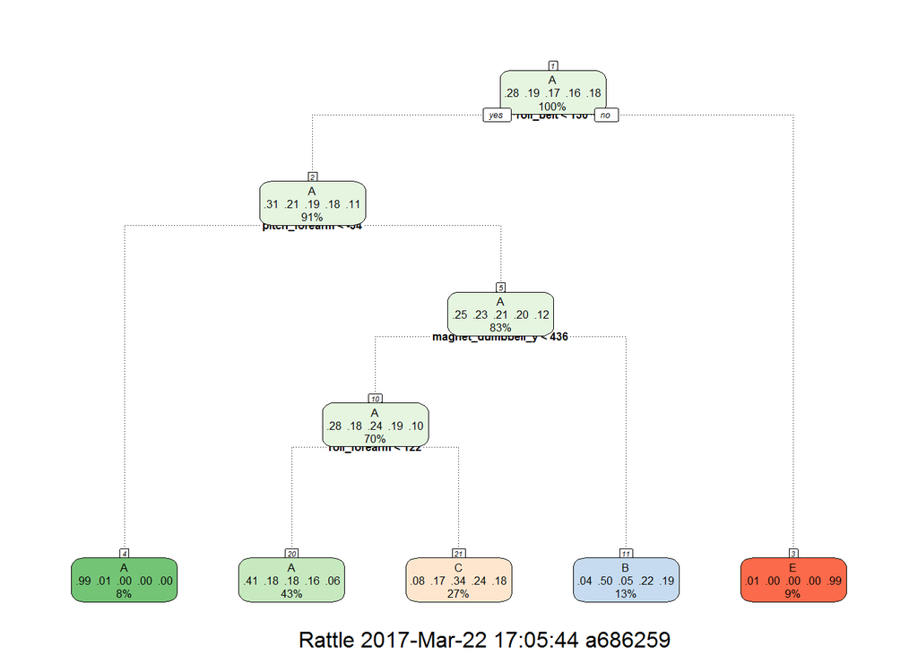

```r
fancyRpartPlot(modFit$finalModel,cex=.5,under.cex=1,shadow.offset=0)
```

```r
pred<-predict(modFit,myTest)
confusionMatrix(myTest$classe,pred)
```

```
## Confusion Matrix and Statistics
##
##           Reference
## Prediction    A    B    C    D    E
##          A 2035   32  160    0    5
##          B  603  516  399    0    0
##          C  659   37  672    0    0
##          D  589  236  461    0    0
##          E  217  192  405    0  628
##
## Overall Statistics
##
##                Accuracy : 0.4908
##                  95% CI : (0.4797, 0.502)
##     No Information Rate : 0.5229
##     P-Value [Acc > NIR] : 1
##
##                   Kappa : 0.3343
##  Mcnemar's Test P-Value : NA
##
## Statistics by Class:
##
##                      Class: A Class: B Class: C Class: D Class: E
## Sensitivity            0.4960  0.50938  0.32046       NA  0.99210
## Specificity            0.9474  0.85336  0.87894   0.8361  0.88715
## Pos Pred Value         0.9117  0.33992  0.49123       NA  0.43551
## Neg Pred Value         0.6316  0.92146  0.78002       NA  0.99922
## Prevalence             0.5229  0.12911  0.26727   0.0000  0.08068
## Detection Rate         0.2594  0.06577  0.08565   0.0000  0.08004
## Detection Prevalence   0.2845  0.19347  0.17436   0.1639  0.18379
## Balanced Accuracy      0.7217  0.68137  0.59970       NA  0.93962
```

The result is disappointing with only 0.4908 accuracy. And the prediction of class D is the worst as none of the test data is predicted as class D. And class E has the highest accuracy which is 0.9921.

### 2.Prediction with Random Forest

As the decision tree didn’t work out, I tried the random forest algorithm next. And in order to prevent overfitting, I used cross validation as the resampling method with 4 folds.

```r
set.seed(201703)
modFit2 <- train(classe ~ ., method="rf",trControl=trainControl(method = "cv", number = 4), data=myTrain)
print(modFit2)
```

```
## Random Forest
##
## 11776 samples
##    52 predictor
##     5 classes: 'A', 'B', 'C', 'D', 'E'
##
## No pre-processing
## Resampling: Cross-Validated (4 fold)
## Summary of sample sizes: 8831, 8831, 8832, 8834
## Resampling results across tuning parameters:
##
##   mtry  Accuracy   Kappa
##    2    0.9880268  0.9848524
##   27    0.9887059  0.9857125
##   52    0.9807233  0.9756130
##
## Accuracy was used to select the optimal model using  the largest value.
## The final value used for the model was mtry = 27.
```

```r
varImp(modFit2)
```

```
## rf variable importance
##
##   only 20 most important variables shown (out of 52)
##
##                      Overall
## roll_belt             100.00
## pitch_forearm          58.27
## yaw_belt               54.21
## pitch_belt             44.32
## magnet_dumbbell_z      43.44
## roll_forearm           41.92
## magnet_dumbbell_y      40.65
## accel_dumbbell_y       20.99
## roll_dumbbell          18.94
## accel_forearm_x        16.60
## magnet_dumbbell_x      15.54
## accel_belt_z           15.05
## magnet_belt_z          14.66
## accel_dumbbell_z       14.62
## total_accel_dumbbell   13.12
## magnet_forearm_z       13.04
## magnet_belt_y          12.53
## yaw_arm                12.06
## gyros_belt_z           10.62
## magnet_belt_x          10.04
```

```r
pred2<-predict(modFit2,myTest)
confusionMatrix(myTest$classe,pred2)
```

```
## Confusion Matrix and Statistics
##
##           Reference
## Prediction    A    B    C    D    E
##          A 2230    2    0    0    0
##          B    9 1503    6    0    0
##          C    0    7 1355    6    0
##          D    0    1   23 1260    2
##          E    0    2    2   12 1426
##
## Overall Statistics
##
##                Accuracy : 0.9908
##                  95% CI : (0.9885, 0.9928)
##     No Information Rate : 0.2854
##     P-Value [Acc > NIR] : < 2.2e-16
##
##                   Kappa : 0.9884
##  Mcnemar's Test P-Value : NA
##
## Statistics by Class:
##
##                      Class: A Class: B Class: C Class: D Class: E
## Sensitivity            0.9960   0.9921   0.9776   0.9859   0.9986
## Specificity            0.9996   0.9976   0.9980   0.9960   0.9975
## Pos Pred Value         0.9991   0.9901   0.9905   0.9798   0.9889
## Neg Pred Value         0.9984   0.9981   0.9952   0.9973   0.9997
## Prevalence             0.2854   0.1931   0.1767   0.1629   0.1820
## Detection Rate         0.2842   0.1916   0.1727   0.1606   0.1817
## Detection Prevalence   0.2845   0.1935   0.1744   0.1639   0.1838
## Balanced Accuracy      0.9978   0.9949   0.9878   0.9910   0.9981
```

The results turned out to be way better than decision tress with 0.9908 accuracy on the testing dataset. And the top five features that have the most impact are roll_belt, pitch_forearm, yaw_belt, pitch_belt and magnet_dumbbell. This model also has 0.98+ accuracy on all classes in this experiment, which proves the effectiveness of this model.

### 3.Prediction with Gradient Boosted Trees

Although the random forest already gave a very powerful prediction, I also wanted to compare it with the gradient boosted trees to see which one works better in this case.

```r
set.seed(201703)
modFit3 <- train(classe ~ ., method="gbm",trControl=trainControl(method = "cv", number = 4), data=myTrain)
```

```r
print(modFit3)
```

```
## Stochastic Gradient Boosting
##
## 11776 samples
##    52 predictor
##     5 classes: 'A', 'B', 'C', 'D', 'E'
##
## No pre-processing
## Resampling: Cross-Validated (4 fold)
## Summary of sample sizes: 8831, 8831, 8832, 8834
## Resampling results across tuning parameters:
##
##   interaction.depth  n.trees  Accuracy   Kappa
##   1                   50      0.7560317  0.6906663
##   1                  100      0.8232022  0.7761735
##   1                  150      0.8547910  0.8162217
##   2                   50      0.8584420  0.8206387
##   2                  100      0.9056555  0.8806221
##   2                  150      0.9294327  0.9107101
##   3                   50      0.8949553  0.8670010
##   3                  100      0.9390289  0.9228321
##   3                  150      0.9569466  0.9455210
##
## Tuning parameter 'shrinkage' was held constant at a value of 0.1
##
## Tuning parameter 'n.minobsinnode' was held constant at a value of 10
## Accuracy was used to select the optimal model using  the largest value.
## The final values used for the model were n.trees = 150,
##  interaction.depth = 3, shrinkage = 0.1 and n.minobsinnode = 10.
```

```r
varImp(modFit3)
```

```
## gbm variable importance
##
##   only 20 most important variables shown (out of 52)
##
##                   Overall
## roll_belt         100.000
## pitch_forearm      49.900
## yaw_belt           39.136
## magnet_dumbbell_z  30.692
## magnet_dumbbell_y  27.975
## roll_forearm       24.293
## magnet_belt_z      19.866
## pitch_belt         18.853
## accel_forearm_x    14.169
## gyros_belt_z       13.730
## accel_dumbbell_y   11.844
## roll_dumbbell      11.277
## accel_forearm_z     9.991
## gyros_dumbbell_y    9.556
## yaw_arm             8.163
## magnet_dumbbell_x   7.111
## accel_dumbbell_x    6.270
## magnet_forearm_z    5.262
## magnet_arm_z        4.853
## magnet_belt_y       4.507
```

```r
pred3<-predict(modFit3,myTest)
confusionMatrix(myTest$classe,pred3)
```

```
## Confusion Matrix and Statistics
##
##           Reference
## Prediction    A    B    C    D    E
##          A 2206   20    2    3    1
##          B   44 1426   42    5    1
##          C    0   34 1312   20    2
##          D    0    4   43 1227   12
##          E    2   13   24   25 1378
##
## Overall Statistics
##
##                Accuracy : 0.9621
##                  95% CI : (0.9577, 0.9663)
##     No Information Rate : 0.287
##     P-Value [Acc > NIR] : < 2.2e-16
##
##                   Kappa : 0.9521
##  Mcnemar's Test P-Value : 1.248e-08
##
## Statistics by Class:
##
##                      Class: A Class: B Class: C Class: D Class: E
## Sensitivity            0.9796   0.9526   0.9220   0.9586   0.9885
## Specificity            0.9954   0.9855   0.9913   0.9910   0.9901
## Pos Pred Value         0.9884   0.9394   0.9591   0.9541   0.9556
## Neg Pred Value         0.9918   0.9888   0.9829   0.9919   0.9975
## Prevalence             0.2870   0.1908   0.1814   0.1631   0.1777
## Detection Rate         0.2812   0.1817   0.1672   0.1564   0.1756
## Detection Prevalence   0.2845   0.1935   0.1744   0.1639   0.1838
## Balanced Accuracy      0.9875   0.9690   0.9566   0.9748   0.9893
```

Gradient boosted trees gave an accuracy of 0.9621, which is a little less than random forest method. And the top five features that have the most impact are roll_belt, pitch_forearm, yaw_belt, magnet_dumbbell_z and magnet_dumbbell_y.

## Step 5: Conclusion and Predicting on the Test Data

To conclude, the random forest method has the highest accuracy which result to the lowest out of sample error rate(1-0.9908=0.0092). So I used the second model to predict the test data and got the following results.

```r
testingAnswers<-predict(modFit2, newdata=testF)
testingAnswers
```

```
##  [1] B A B A A E D B A A B C B A E E A B B B
## Levels: A B C D E
```

```r
pml_write_files = function(x){
  n = length(x)
  for(i in 1:n){
    filename = paste0("problem_id_",i,".txt")
    write.table(x[i],file=filename,quote=FALSE,row.names=FALSE,col.names=FALSE)
  }
}
```